# SMDM Assignment

Harshit

November 10, 2016

# R Assignment - Pune Census Case

Objective of the analysis : The district collector would like to analysis this data with the objective of evaluating the status of the Female population across the district. This statistical analysis should support in taking decisions to run government programs focusing on different areas of Female population such as female literacy, female child welfare, sex ratios, female employment etc.

Below are the inputs to be considered for your analysis:

The CD blocks need to be divided into three categories as below:  
Category A : total population upto 2 lacs  
Category B : total population between 2-5 lacs  
Category C : total population above 5 lacs

The towns need to be divided into three categories as below:  
Category T1 : total population upto 15K  
Category T2 : total population between 15-25K  
Category T3 : total population above 25K

The villages need to be divided into four categories as below:  
Category V1 : total population upto 2500  
Category V2 : total population between 2500-10,000  
Category V3 : total population between 10,000-40,000  
Catgeory V4 : total population above 40,000

Using R execute a statistical analysis as per the above buckets, and help the district collector to understand the following:  
Sex ratio(per 1000)  
Child sex ratio (0-6 age)  
Average literacy rate  
Female literacy rate  
Child proportion(0-6 age)  
Girls proportion(0-6 age)  
Averge percentage of worker population female  
Proportion of Main : Marginal worker population female  
Within female Main worker population the proportion of Main :Main cultivator : Main agri labour: Main houshold industry :Main other  
Average number of child(0-6) per household  
Average number of girl child(0-6) per household  
Average percentage non working population female

Is there a significant difference in the above parameters between the top and the lowest category levels of each of the CD block(A/C), Village(V1/v4) and Towns(T1/T3)?  
Is there a significant difference in the average literacy rate, child sex ratio, Female literacy rate , average female worker population between Urban and Rural ?  
Is there a relationship between the female literacy rate and the average percentage worker population female in the villages?

Overall Rural vs Urban Sex ratio  
Pune district population density: Pune district administers 15,643 square kilometers of areas  
Top 5 highest literacy rate towns, village and district blocks  
Top 5 highest female literacy rate towns, village and district blocks  
Bottom 5 lowest literacy rate towns, village and district blocks  
Bottom 5 lowest female literacy rate towns, village and district blocks  
Lowest sex ratio towns, village and district blocks in each category

## Solution with Output

### Reading CSV file

```r
Census <- read.csv(file.choose())
```

### Creating subsets for CD Blocks, Towns and Villages

```r
attach(Census)
CDBlocks <- subset(Census, Level=="CD BLOCK" & Total.Rural.Urban=="Total")
CDBlocksN <- subset(Census, Level=="CD BLOCK" & Total.Rural.Urban!="Total")
Town <- subset(Census, Level=="TOWN")
Village <- subset(Census, Level=="VILLAGE")
detach(Census)
```

### Creating Categories in those subsets

```r
attach(CDBlocks)
CDCat <- ifelse(Total.Population.Person <= 200000, 'A',
                ifelse(Total.Population.Person > 200000 & Total.Population.Person <= 500000, 'B',
                       ifelse(Total.Population.Person > 500000, 'C','F')))

CDBlockCat <- data.frame(CDBlocks,CDCat)
detach(CDBlocks)

attach(Town)
TCat <- ifelse(Total.Population.Person <= 15000, "T1",
                  ifelse(Total.Population.Person > 15000 & Total.Population.Person <= 25000, "T2",
                         ifelse(Total.Population.Person > 25000, "T3", "T9")))

TownCat <- data.frame(Town,TCat)
detach(Town)


attach(Village)
VCat <- ifelse(Total.Population.Person <= 2500, "V1",
               ifelse(Total.Population.Person > 2500 & Total.Population.Person <= 10000, "V2",
                      ifelse(Total.Population.Person > 10000 & Total.Population.Person <= 40000, "V3",
                             ifelse(Total.Population.Person > 40000, "V4", "V9"))))

VillageCat <- data.frame(Village,VCat)
detach(Village)

myvars <- c("CD.Block_Code", "CDCat")
CatCD <- CDBlockCat[myvars]
CDBlockCat2 <- merge(CDBlocksN, CatCD, by="CD.Block_Code")
```

### Calculating Ratios

#### CD Block Ratios

```r
library("plyr", lib.loc="~/R/win-library/3.3")

CDBlockRatios <- ddply(CDBlockCat2,"CDCat",summarize,SexRatio=((sum(Total.Population.Female)/sum(Total.Population.Male))*1000),
      ChildSexRatio=((sum(Population.in.the.age.group.0.6.Female)/sum(Population.in.the.age.group.0.6.Male))*1000),
      AvgLiteracyRate=((mean(Literates.Population.Person)/mean(Total.Population.Person - Population.in.the.age.group.0.6.Person))*100),
      FemaleLiteracyRate=((sum(Literates.Population.Female)/sum(Total.Population.Female - Population.in.the.age.group.0.6.Female))*100),
      ChildProportion=(sum(Population.in.the.age.group.0.6.Person)/sum(Total.Population.Person)),
      GirlsProportion=(sum(Population.in.the.age.group.0.6.Female)/sum(Population.in.the.age.group.0.6.Person)),
      AvgPercentFemaleWorker=((mean(Total.Worker.Population.Female)/mean(Total.Worker.Population.Person))*100),
      MainMarginalWorkerFemale=sum(Main.Working.Population.Female)/sum(Marginal.Worker.Population.Female),
      CultivatorToWorker=(sum(Main.Cultivator.Population.Female)/sum(Main.Working.Population.Female)),
      AgriLabourToWorker=(sum(Main.Agricultural.Labourers.Population.Female)/sum(Main.Working.Population.Female)),
      HouseholdToWorker=(sum(Main.Household.Industries.Population.Female)/sum(Main.Working.Population.Female)),
      OtherToWorker=(sum(Main.Other.Workers.Population.Female)/sum(Main.Working.Population.Female)),
      AvgChildPerHousehold=(mean(Population.in.the.age.group.0.6.Person)/mean(No.of.Households)),
      AvgGirlChildPerHousehold=(mean(Population.in.the.age.group.0.6.Female)/mean(No.of.Households)),
      AvgNonWorkingPopFemale=((mean(Non.Working.Population.Female)/mean(Non.Working.Population.Person))*100))

#CD Block Ratios
CDBlockRatios
```

```
##   CDCat SexRatio ChildSexRatio AvgLiteracyRate FemaleLiteracyRate
## 1     A 943.6923      888.9674        80.03457           71.61090
## 2     B 932.0107      868.5137        80.91965           73.26415
## 3     C 894.3313      857.5973        85.19992           79.26095
##   ChildProportion GirlsProportion AvgPercentFemaleWorker
## 1       0.1177750       0.4706103               39.46422
## 2       0.1184131       0.4648153               40.22818
## 3       0.1347173       0.4616702               27.35288
##   MainMarginalWorkerFemale CultivatorToWorker AgriLabourToWorker
## 1                 4.661909          0.6037235          0.1928253
## 2                 8.191461          0.5445111          0.3046652
## 3                 5.873065          0.3051085          0.2039359
##   HouseholdToWorker OtherToWorker AvgChildPerHousehold
## 1        0.02691742     0.1765337            0.5429896
## 2        0.01848877     0.1323349            0.5625962
## 3        0.05239521     0.4385604            0.5975256
##   AvgGirlChildPerHousehold AvgNonWorkingPopFemale
## 1                0.2555365               57.84109
## 2                0.2615033               56.34638
## 3                0.2758597               61.37866
```

#### Town Ratios

```r
TownRatios <- ddply(TownCat,"TCat",summarize,SexRatio=((sum(Total.Population.Female)/sum(Total.Population.Male))*1000),
      ChildSexRatio=((sum(Population.in.the.age.group.0.6.Female)/sum(Population.in.the.age.group.0.6.Male))*1000),
      AvgLiteracyRate=((mean(Literates.Population.Person)/mean(Total.Population.Person - Population.in.the.age.group.0.6.Person))*100),
      FemaleLiteracyRate=((sum(Literates.Population.Female)/sum(Total.Population.Female - Population.in.the.age.group.0.6.Female))*100),
      ChildProportion=(sum(Population.in.the.age.group.0.6.Person)/sum(Total.Population.Person)),
      GirlsProportion=(sum(Population.in.the.age.group.0.6.Female)/sum(Population.in.the.age.group.0.6.Person)),
      AvgPercentFemaleWorker=((mean(Total.Worker.Population.Female)/mean(Total.Worker.Population.Person))*100),
      MainMarginalWorkerFemale=sum(Main.Working.Population.Female)/sum(Marginal.Worker.Population.Female),
      CultivatorToWorker=(sum(Main.Cultivator.Population.Female)/sum(Main.Working.Population.Female)),
      AgriLabourToWorker=(sum(Main.Agricultural.Labourers.Population.Female)/sum(Main.Working.Population.Female)),
      HouseholdToWorker=(sum(Main.Household.Industries.Population.Female)/sum(Main.Working.Population.Female)),
      OtherToWorker=(sum(Main.Other.Workers.Population.Female)/sum(Main.Working.Population.Female)),
      AvgChildPerHousehold=(mean(Population.in.the.age.group.0.6.Person)/mean(No.of.Households)),
      AvgGirlChildPerHousehold=(mean(Population.in.the.age.group.0.6.Female)/mean(No.of.Households)),
      AvgNonWorkingPopFemale=((mean(Non.Working.Population.Female)/mean(Non.Working.Population.Person))*100))

#Town Ratios
TownRatios
```

```
##   TCat SexRatio ChildSexRatio AvgLiteracyRate FemaleLiteracyRate
## 1   T1 850.5653      847.3477        87.20540           82.10408
## 2   T2 885.0100      888.4236        89.37312           84.97646
## 3   T3 886.8331      854.7531        87.64341           83.87735
##   ChildProportion GirlsProportion AvgPercentFemaleWorker
## 1       0.1436578       0.4586834               21.17377
## 2       0.1172679       0.4704578               25.01466
## 3       0.1400670       0.4608447               22.66477
##   MainMarginalWorkerFemale CultivatorToWorker AgriLabourToWorker
## 1                 5.214958          0.1011492         0.07455599
## 2                 6.172783          0.1245975         0.08645033
## 3                 6.079774          0.1039099         0.06746190
##   HouseholdToWorker OtherToWorker AvgChildPerHousehold
## 1        0.07693038     0.7473644            0.5867985
## 2        0.05697300     0.7319792            0.5529958
## 3        0.07037773     0.7582505            0.5848859
##   AvgGirlChildPerHousehold AvgNonWorkingPopFemale
## 1                0.2691547               62.77074
## 2                0.2601612               58.67564
## 3                0.2695416               62.47355
```

#### Village Ratios

```r
VillageRatios <- ddply(VillageCat,"VCat",summarize,SexRatio=((sum(Total.Population.Female)/sum(Total.Population.Male))*1000),
      ChildSexRatio=((sum(Population.in.the.age.group.0.6.Female)/sum(Population.in.the.age.group.0.6.Male))*1000),
      AvgLiteracyRate=((mean(Literates.Population.Person)/mean(Total.Population.Person - Population.in.the.age.group.0.6.Person))*100),
      FemaleLiteracyRate=((sum(Literates.Population.Female)/sum(Total.Population.Female - Population.in.the.age.group.0.6.Female))*100),
      ChildProportion=(sum(Population.in.the.age.group.0.6.Person)/sum(Total.Population.Person)),
      GirlsProportion=(sum(Population.in.the.age.group.0.6.Female)/sum(Population.in.the.age.group.0.6.Person)),
      AvgPercentFemaleWorker=((mean(Total.Worker.Population.Female)/mean(Total.Worker.Population.Person))*100),
      MainMarginalWorkerFemale=sum(Main.Working.Population.Female)/sum(Marginal.Worker.Population.Female),
      CultivatorToWorker=(sum(Main.Cultivator.Population.Female)/sum(Main.Working.Population.Female)),
      AgriLabourToWorker=(sum(Main.Agricultural.Labourers.Population.Female)/sum(Main.Working.Population.Female)),
      HouseholdToWorker=(sum(Main.Household.Industries.Population.Female)/sum(Main.Working.Population.Female)),
      OtherToWorker=(sum(Main.Other.Workers.Population.Female)/sum(Main.Working.Population.Female)),
      AvgChildPerHousehold=(mean(Population.in.the.age.group.0.6.Person)/mean(No.of.Households)),
      AvgGirlChildPerHousehold=(mean(Population.in.the.age.group.0.6.Female)/mean(No.of.Households)),
      AvgNonWorkingPopFemale=((mean(Non.Working.Population.Female)/mean(Non.Working.Population.Person))*100))

#Village Ratios
VillageRatios
```

```
##   VCat SexRatio ChildSexRatio AvgLiteracyRate FemaleLiteracyRate
## 1   V1 954.5543      889.5897        78.37244           69.40420
## 2   V2 926.9032      858.6706        81.41359           74.04796
## 3   V3 897.9564      862.6513        85.41298           79.71637
## 4   V4 901.6667      854.2000        88.68483           84.14535
##   ChildProportion GirlsProportion AvgPercentFemaleWorker
## 1       0.1148131       0.4707846               43.62064
## 2       0.1193783       0.4619811               39.14817
## 3       0.1298270       0.4631309               28.32958
## 4       0.1403379       0.4606839               20.96456
##   MainMarginalWorkerFemale CultivatorToWorker AgriLabourToWorker
## 1                 6.032640          0.6345257          0.2593510
## 2                 9.124164          0.5166513          0.3139195
## 3                 6.764486          0.2792433          0.2779616
## 4                 4.646804          0.1492189          0.2056423
##   HouseholdToWorker OtherToWorker AvgChildPerHousehold
## 1        0.01388639    0.09223691            0.5584908
## 2        0.02488085    0.14454834            0.5635821
## 3        0.03971576    0.40307927            0.5751619
## 4        0.04639776    0.59874097            0.5944854
##   AvgGirlChildPerHousehold AvgNonWorkingPopFemale
## 1                0.2629289               54.84750
## 2                0.2603643               56.91948
## 3                0.2663752               61.08833
## 4                0.2738698               63.37468
```

#### Rural vs Urban Ratios

```r
RuralUrbanRatios <- ddply(CDBlockCat2,"Total.Rural.Urban",summarize,SexRatio=((sum(Total.Population.Female)/sum(Total.Population.Male))*1000),
      ChildSexRatio=((sum(Population.in.the.age.group.0.6.Female)/sum(Population.in.the.age.group.0.6.Male))*1000),
      AvgLiteracyRate=((mean(Literates.Population.Person)/mean(Total.Population.Person))*100),
      FemaleLiteracyRate=((sum(Literates.Population.Female)/sum(Total.Population.Female))*100),
      ChildProportion=(sum(Population.in.the.age.group.0.6.Person)/sum(Total.Population.Person)),
      GirlsProportion=(sum(Population.in.the.age.group.0.6.Female)/sum(Population.in.the.age.group.0.6.Person)),
      AvgPercentFemaleWorker=((mean(Total.Worker.Population.Female)/mean(Total.Worker.Population.Person))*100),
      MainMarginalWorkerFemale=sum(Main.Working.Population.Female)/sum(Marginal.Worker.Population.Female),
      CultivatorToWorker=(sum(Main.Cultivator.Population.Female)/sum(Main.Working.Population.Female)),
      AgriLabourToWorker=(sum(Main.Agricultural.Labourers.Population.Female)/sum(Main.Working.Population.Female)),
      HouseholdToWorker=(sum(Main.Household.Industries.Population.Female)/sum(Main.Working.Population.Female)),
      OtherToWorker=(sum(Main.Other.Workers.Population.Female)/sum(Main.Working.Population.Female)),
      AvgChildPerHousehold=(mean(Population.in.the.age.group.0.6.Person)/mean(No.of.Households)),
      AvgGirlChildPerHousehold=(mean(Population.in.the.age.group.0.6.Female)/mean(No.of.Households)),
      AvgNonWorkingPopFemale=((mean(Non.Working.Population.Female)/mean(Non.Working.Population.Person))*100))

#Rural vs Urban Ratios
RuralUrbanRatios
```

```
##   Total.Rural.Urban SexRatio ChildSexRatio AvgLiteracyRate
## 1             Rural 932.4097      870.8002        71.29040
## 2             Urban 868.6197      856.0144        75.66257
##   FemaleLiteracyRate ChildProportion GirlsProportion
## 1           64.79829       0.1196506       0.4654694
## 2           71.85695       0.1377330       0.4612111
##   AvgPercentFemaleWorker MainMarginalWorkerFemale CultivatorToWorker
## 1               39.31287                 7.153319          0.5449746
## 2               22.28549                 5.649208          0.1063724
##   AgriLabourToWorker HouseholdToWorker OtherToWorker AvgChildPerHousehold
## 1         0.28465945        0.02143805     0.1489279            0.5642536
## 2         0.07430691        0.07105061     0.7482701            0.5807376
##   AvgGirlChildPerHousehold AvgNonWorkingPopFemale
## 1                0.2626428               57.08768
## 2                0.2678426               61.88888
```

### *Question : Is there a significant difference in the above parameters between the top and the lowest category levels of each of the CD block(A/C), Village(V1/v4) and Towns(T1/T3)?*

**Check the graphs below for the difference in the above parameters between top and lowest category levels of CD Blocks**

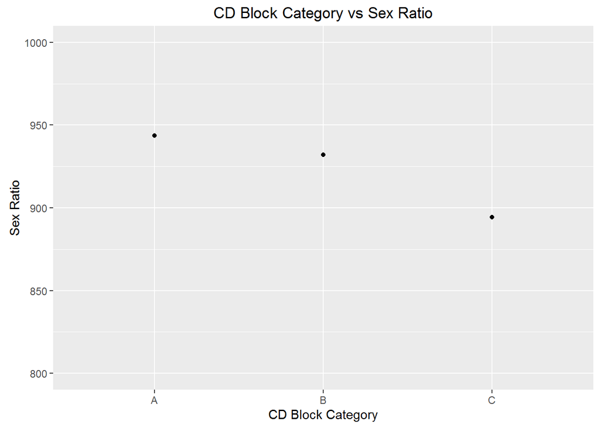

```r
qplot(CDCat, SexRatio, data=CDBlockRatios, xlab="CD Block Category", ylab="Sex Ratio", main="CD Block Category vs Sex Ratio", ylim=c(800,1000))
```

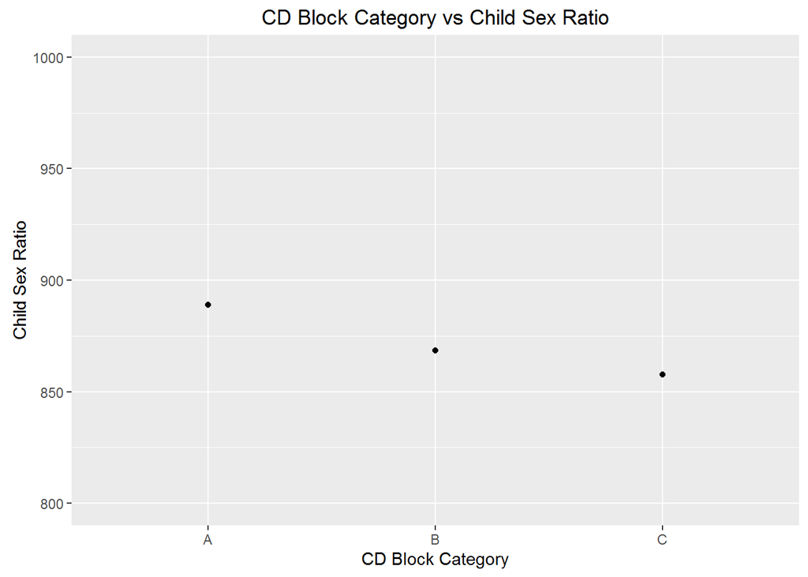

```r
qplot(CDCat, ChildSexRatio, data=CDBlockRatios, xlab="CD Block Category", ylab="Child Sex Ratio", main="CD Block Category vs Child Sex Ratio", ylim=c(800,1000))
```

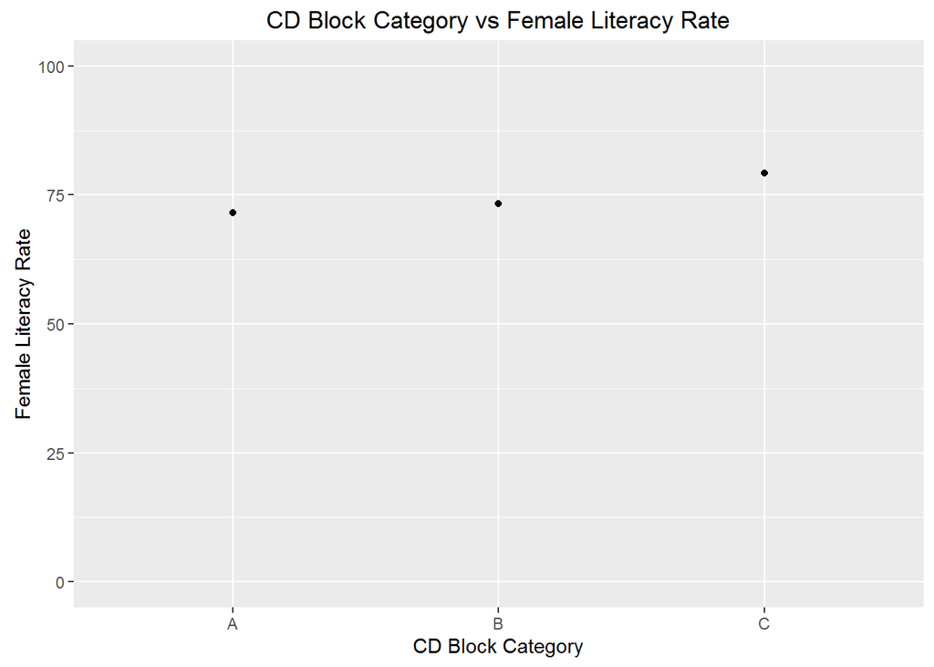

```r
qplot(CDCat, FemaleLiteracyRate, data=CDBlockRatios, xlab="CD Block Category", ylab="Female Literacy Rate", main="CD Block Category vs Female Literacy Rate", ylim=c(0,100))
```

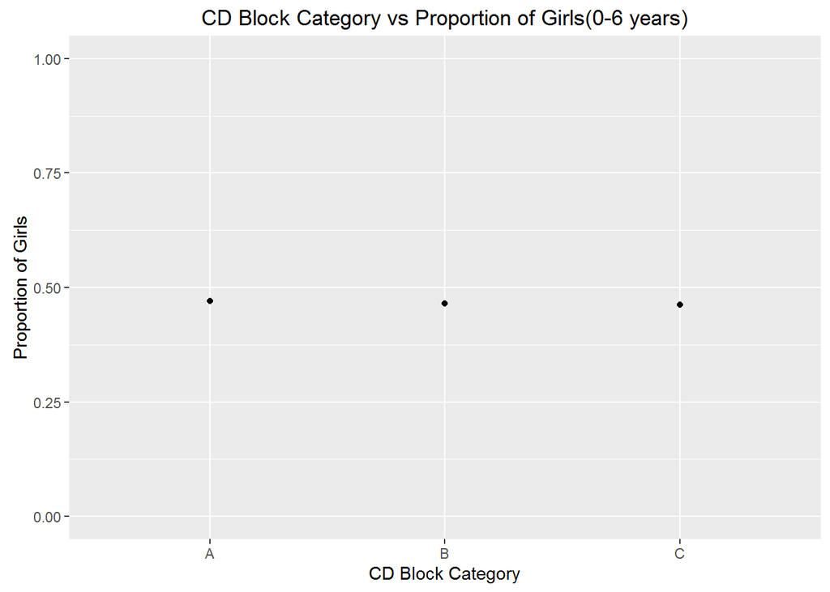

```r
qplot(CDCat, GirlsProportion, data=CDBlockRatios, xlab="CD Block Category", ylab="Proportion of Girls", main="CD Block Category vs Proportion of Girls(0-6 years)", ylim=c(0,1))
```

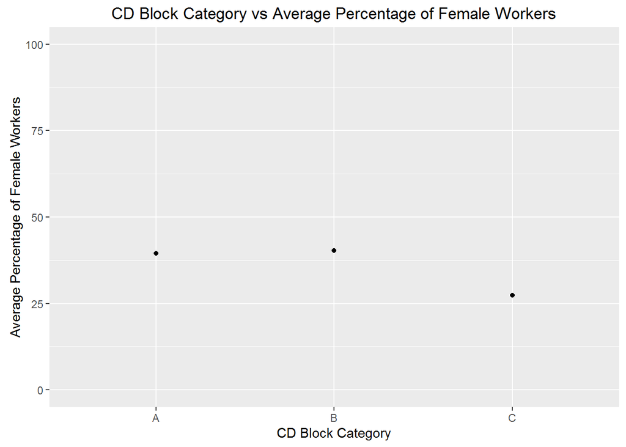

```r
qplot(CDCat, AvgPercentFemaleWorker, data=CDBlockRatios, xlab="CD Block Category", ylab="Average Percentage of Female Workers", main="CD Block Category vs Average Percentage of Female Workers", ylim=c(0,100))
```

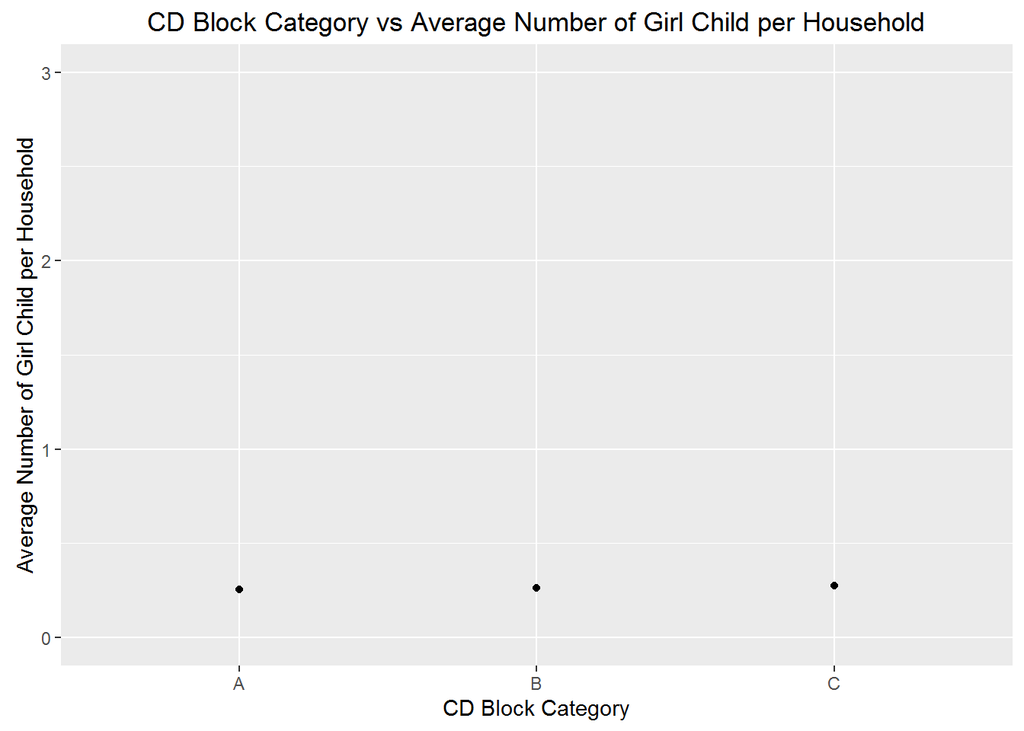

```r
qplot(CDCat, AvgGirlChildPerHousehold, data=CDBlockRatios, xlab="CD Block Category", ylab="Average Number of Girl Child per Household", main="CD Block Category vs Average Number of Girl Child per Household", ylim=c(0,3))
```

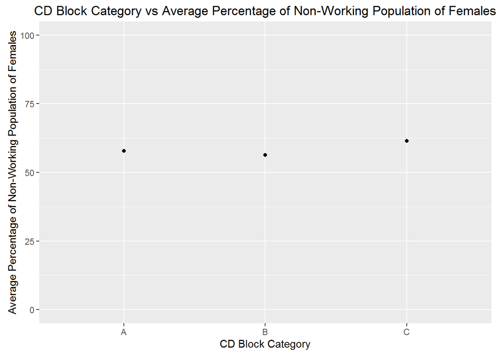

```r
qplot(CDCat, AvgNonWorkingPopFemale, data=CDBlockRatios, xlab="CD Block Category", ylab="Average Percentage of Non-Working Population of Females", main="CD Block Category vs Average Percentage of Non-Working Population of Females", ylim=c(0,100))
```

**Check the graphs below for the difference in the above parameters between top and lowest category levels of Towns**

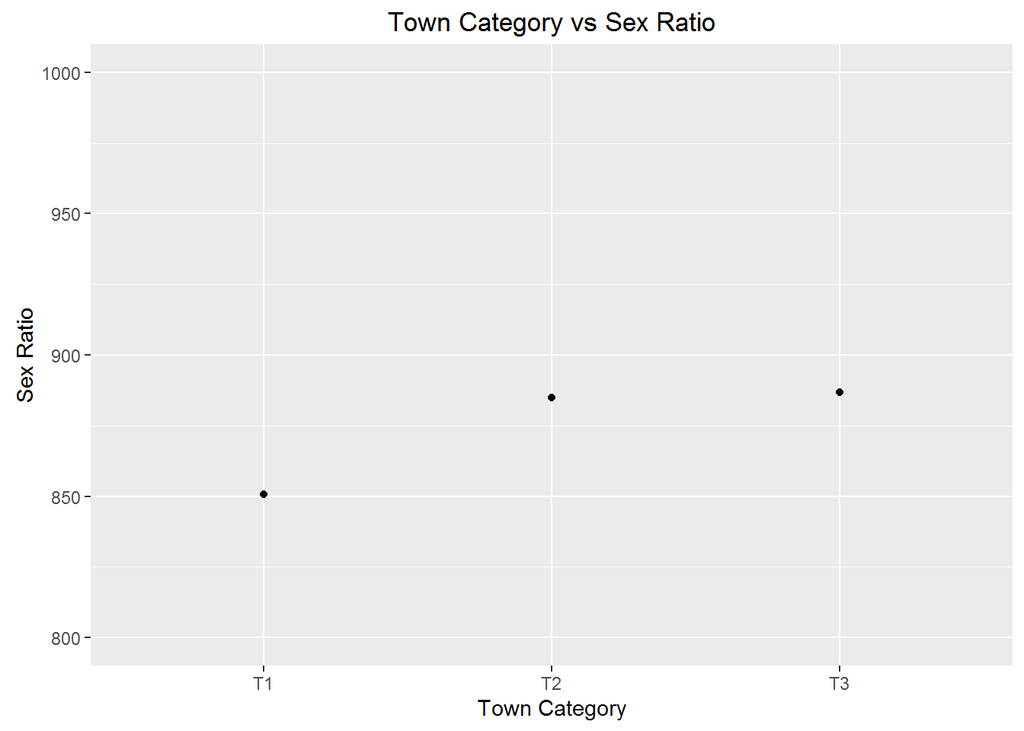

```r
qplot(TCat, SexRatio, data=TownRatios, xlab="Town Category", ylab="Sex Ratio", main="Town Category vs Sex Ratio", ylim=c(800,1000))
```

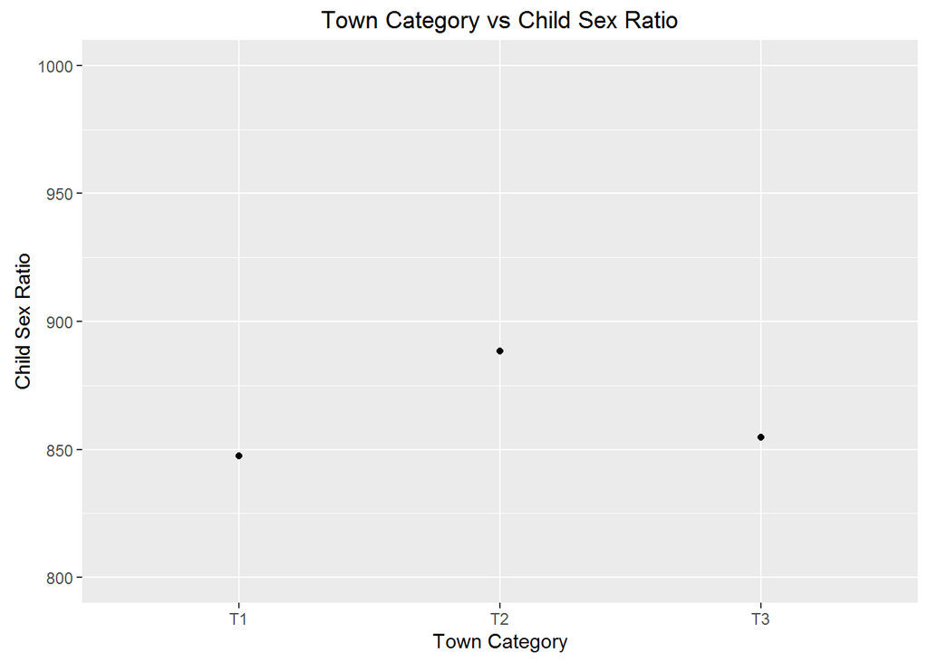

```r
qplot(TCat, ChildSexRatio, data=TownRatios, xlab="Town Category", ylab="Child Sex Ratio", main="Town Category vs Child Sex Ratio", ylim=c(800,1000))
```

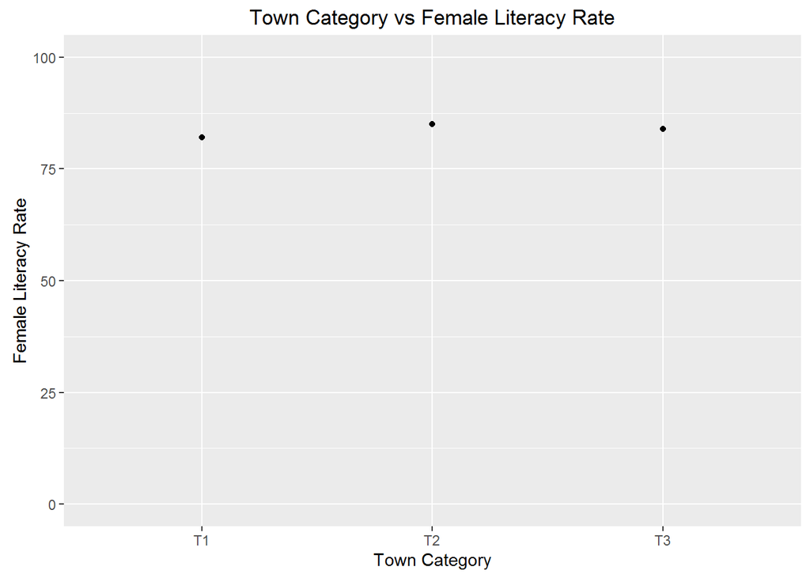

```r
qplot(TCat, FemaleLiteracyRate, data=TownRatios, xlab="Town Category", ylab="Female Literacy Rate", main="Town Category vs Female Literacy Rate", ylim=c(0,100))
```

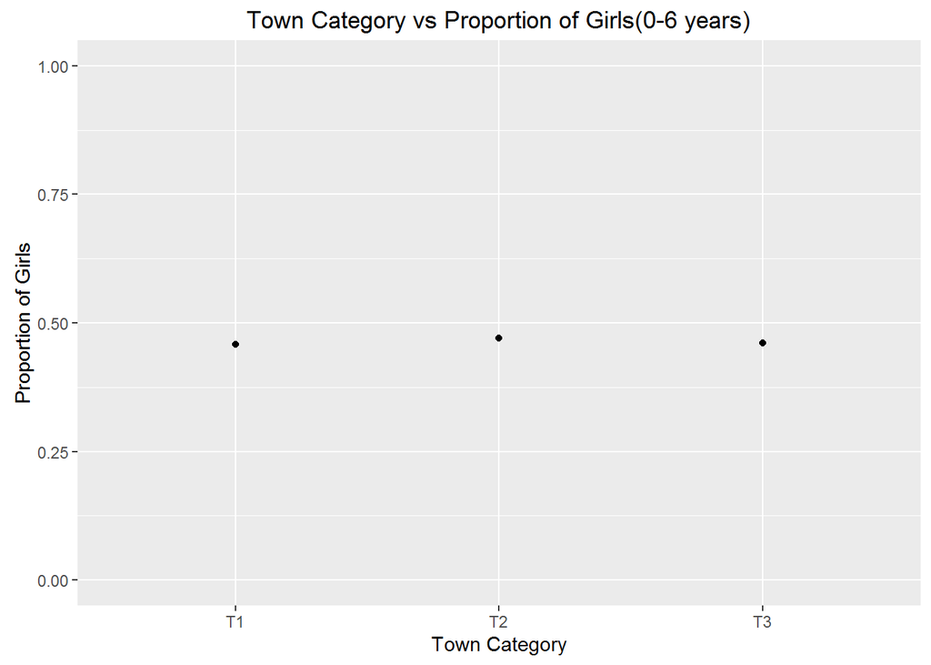

```r
qplot(TCat, GirlsProportion, data=TownRatios, xlab="Town Category", ylab="Proportion of Girls", main="Town Category vs Proportion of Girls(0-6 years)", ylim=c(0,1))
```

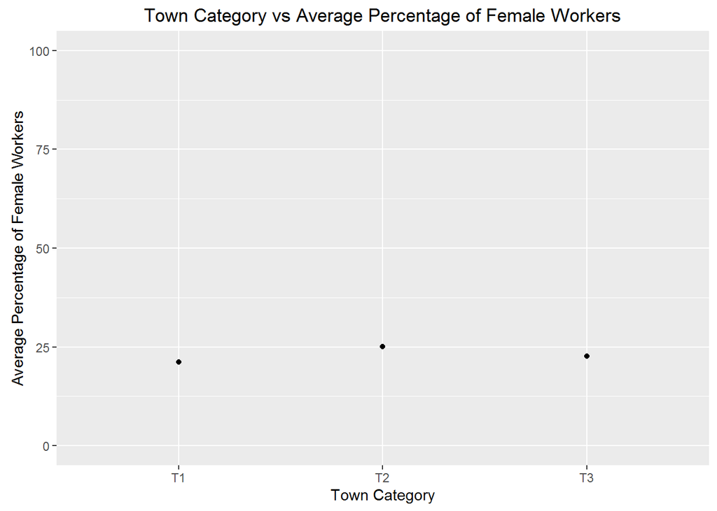

```r
qplot(TCat, AvgPercentFemaleWorker, data=TownRatios, xlab="Town Category", ylab="Average Percentage of Female Workers", main="Town Category vs Average Percentage of Female Workers", ylim=c(0,100))
```

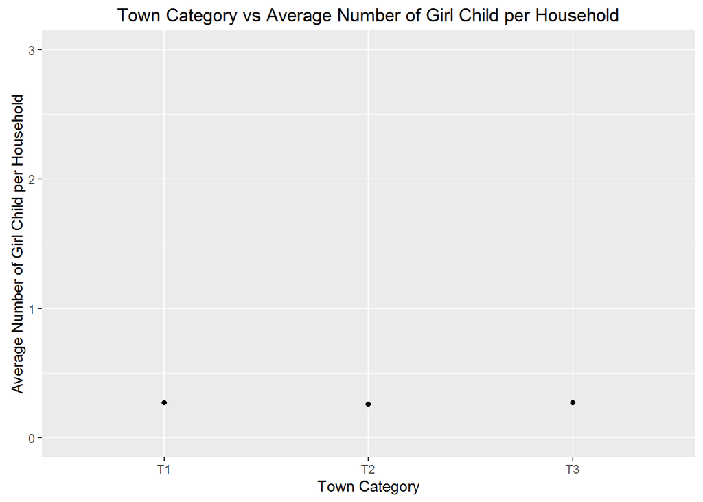

```r
qplot(TCat, AvgGirlChildPerHousehold, data=TownRatios, xlab="Town Category", ylab="Average Number of Girl Child per Household", main="Town Category vs Average Number of Girl Child per Household", ylim=c(0,3))
```

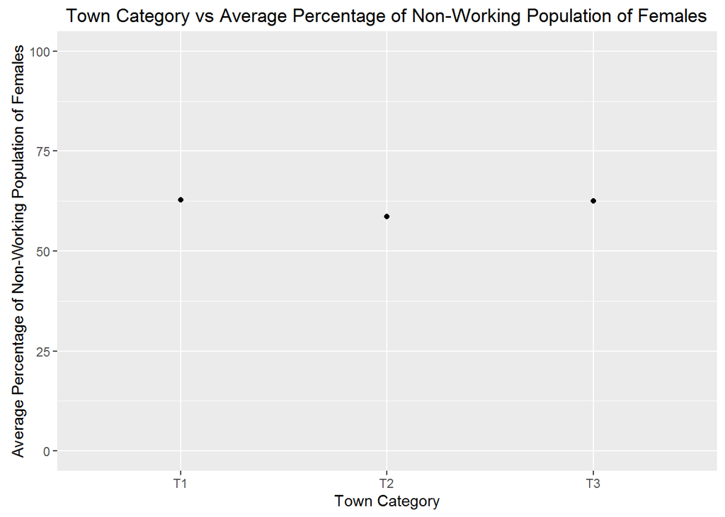

```r
qplot(TCat, AvgNonWorkingPopFemale, data=TownRatios, xlab="Town Category", ylab="Average Percentage of Non-Working Population of Females", main="Town Category vs Average Percentage of Non-Working Population of Females", ylim=c(0,100))
```

> **There is significant difference in Sex Ratio between Town category T1 and T3. The rest of the ratios do not have much variation between the two.**

**Check the graphs below for the difference in the above parameters between top and lowest category levels of Villages**

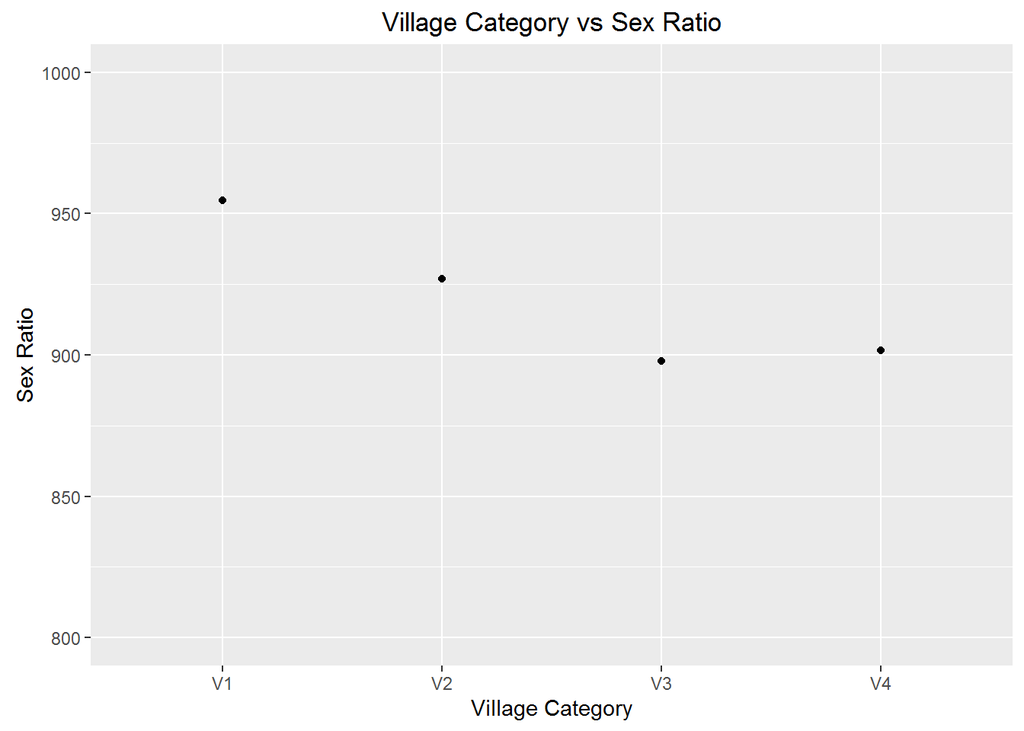

```r
qplot(VCat, SexRatio, data=VillageRatios, xlab="Village Category", ylab="Sex Ratio", main="Village Category vs Sex Ratio", ylim=c(800,1000))
```

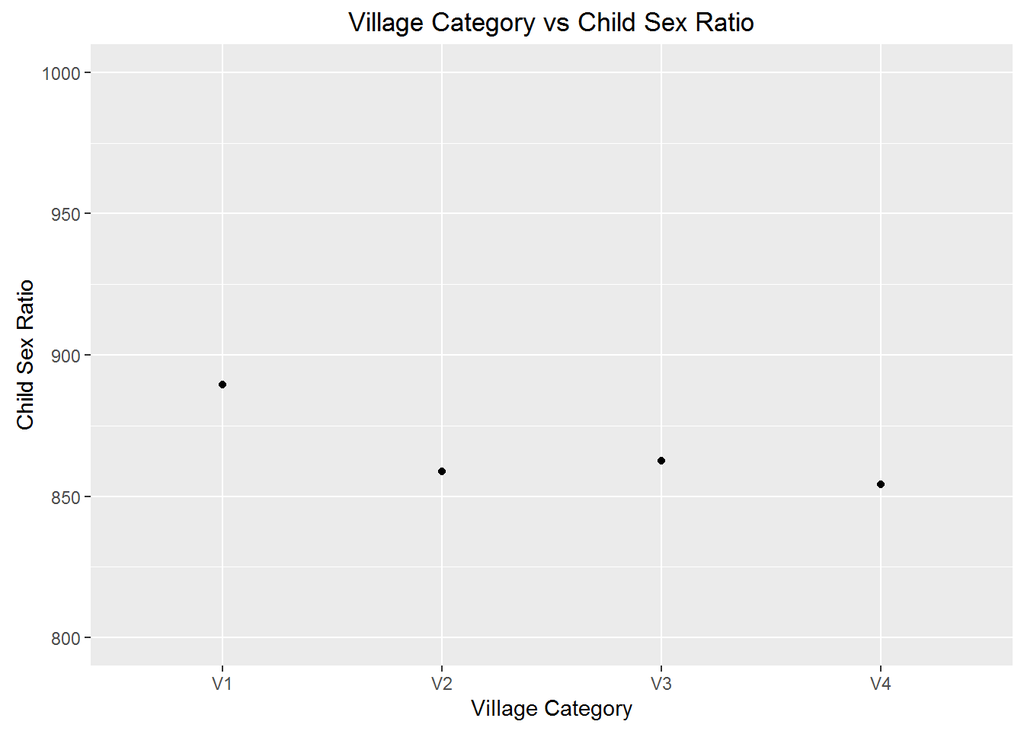

```r
qplot(VCat, ChildSexRatio, data=VillageRatios, xlab="Village Category", ylab="Child Sex Ratio", main="Village Category vs Child Sex Ratio", ylim=c(800,1000))
```

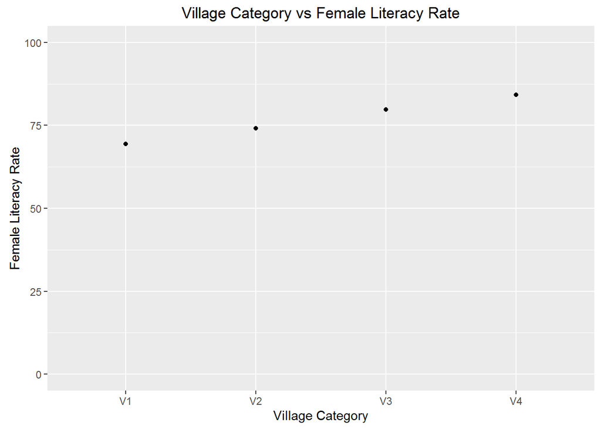

```r
qplot(VCat, FemaleLiteracyRate, data=VillageRatios, xlab="Village Category", ylab="Female Literacy Rate", main="Village Category vs Female Literacy Rate", ylim=c(0,100))
```

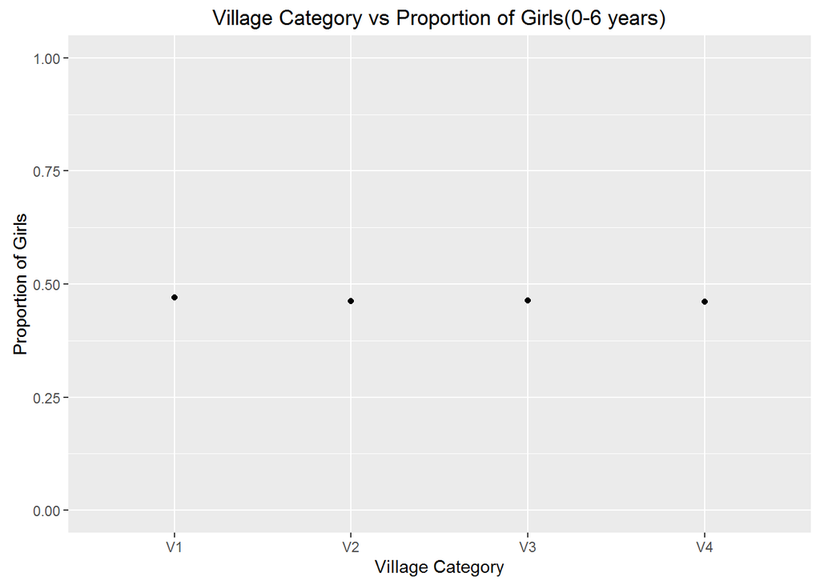

```r
qplot(VCat, GirlsProportion, data=VillageRatios, xlab="Village Category", ylab="Proportion of Girls", main="Village Category vs Proportion of Girls(0-6 years)", ylim=c(0,1))
```

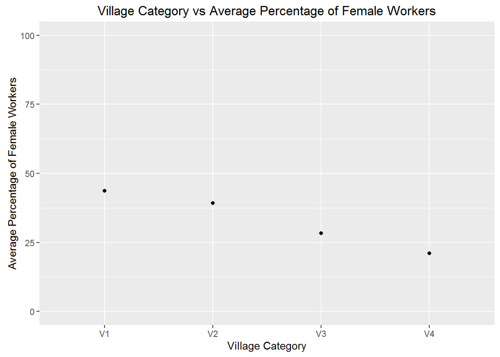

```r
qplot(VCat, AvgPercentFemaleWorker, data=VillageRatios, xlab="Village Category", ylab="Average Percentage of Female Workers", main="Village Category vs Average Percentage of Female Workers", ylim=c(0,100))
```

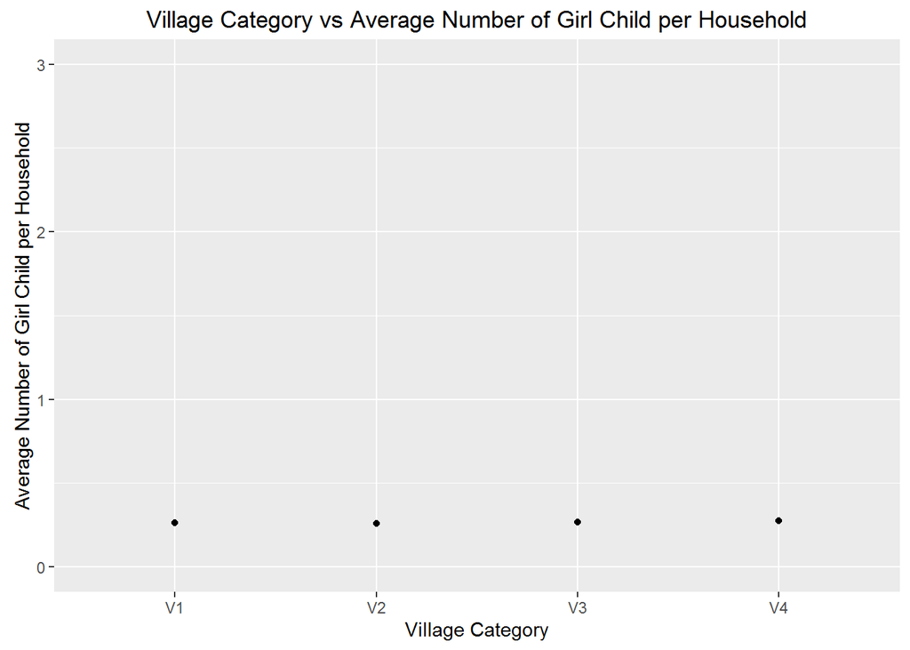

```r
qplot(VCat, AvgGirlChildPerHousehold, data=VillageRatios, xlab="Village Category", ylab="Average Number of Girl Child per Household", main="Village Category vs Average Number of Girl Child per Household", ylim=c(0,3))
```

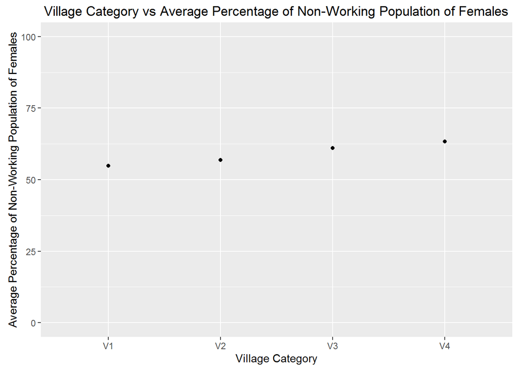

```r
qplot(VCat, AvgNonWorkingPopFemale, data=VillageRatios, xlab="Village Category", ylab="Average Percentage of Non-Working Population of Females", main="Village Category vs Average Percentage of Non-Working Population of Females", ylim=c(0,100))
```

> **There is significant difference in Sex Ratio, Child Sex Ratio, Female Literacy Rate and Average Percenatge of Female Workers between Villages of category V1 and V4. There is not much defference in the other ratios.**

### *Question : Is there a significant difference in the average literacy rate, child sex ratio, Female literacy rate , average female worker population between Urban and Rural?*

**Check the graphs below for the differences between Rural and Urban**

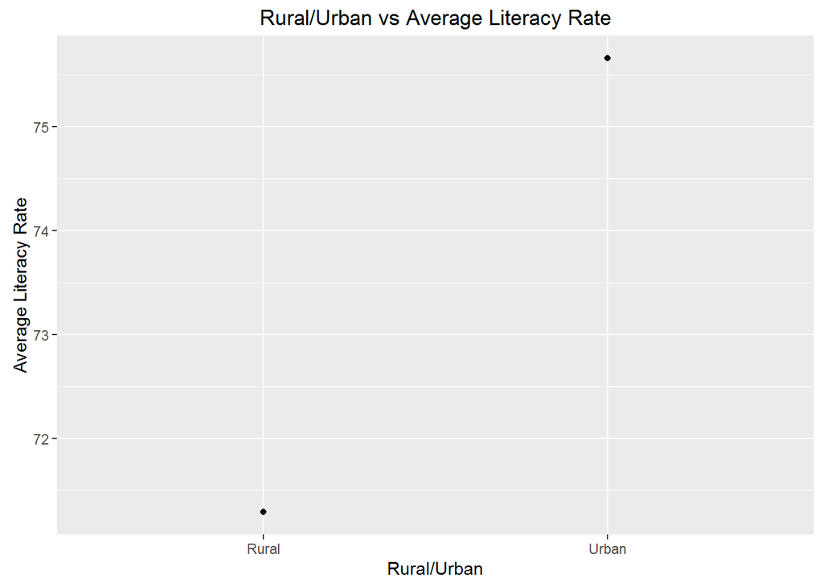

```r
qplot(Total.Rural.Urban, AvgLiteracyRate, data=RuralUrbanRatios, xlab="Rural/Urban", ylab="Average Literacy Rate", main="Rural/Urban vs Average Literacy Rate")
```

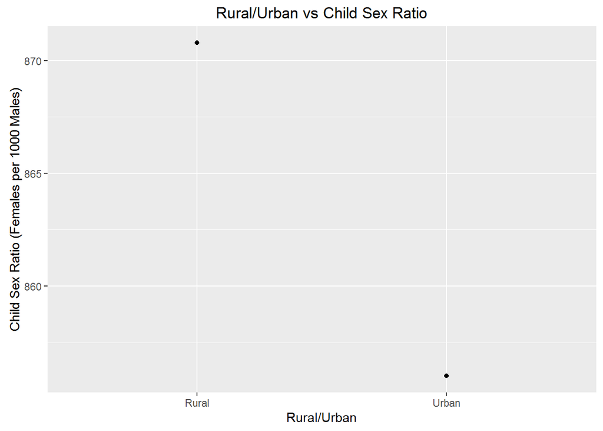

```r
qplot(Total.Rural.Urban, ChildSexRatio, data=RuralUrbanRatios, xlab="Rural/Urban", ylab="Child Sex Ratio (Females per 1000 Males)", main="Rural/Urban vs Child Sex Ratio")
```

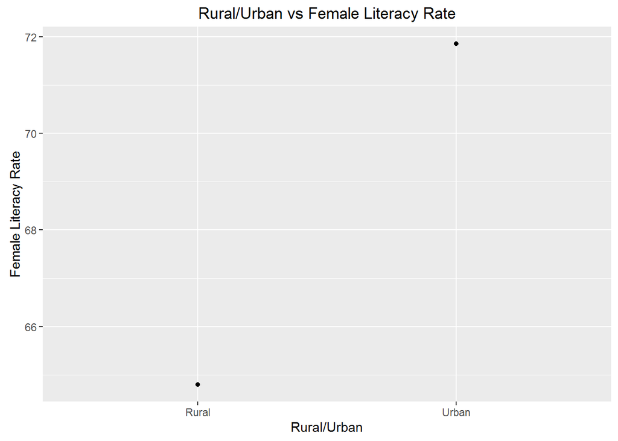

```r
qplot(Total.Rural.Urban, FemaleLiteracyRate, data=RuralUrbanRatios, xlab="Rural/Urban", ylab="Female Literacy Rate", main="Rural/Urban vs Female Literacy Rate")
```

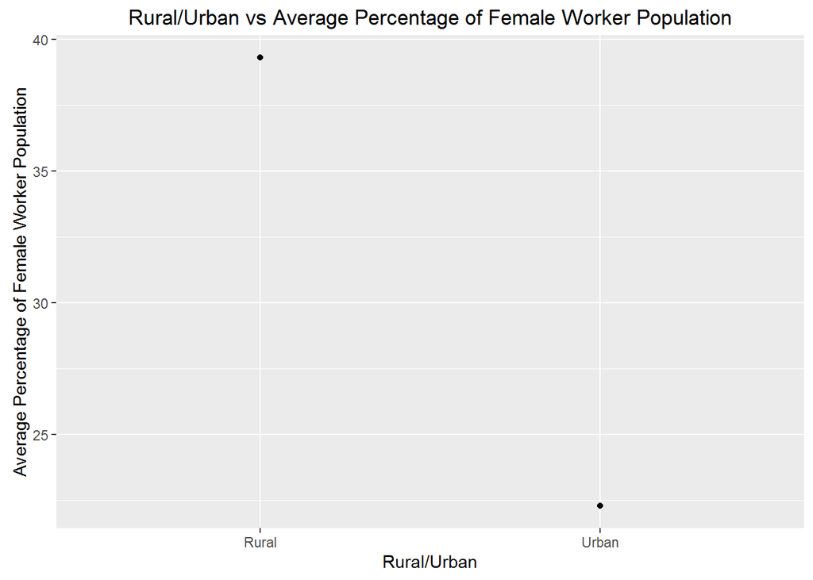

```r
qplot(Total.Rural.Urban, AvgPercentFemaleWorker, data=RuralUrbanRatios, xlab="Rural/Urban", ylab="Average Percentage of Female Worker Population", main="Rural/Urban vs Average Percentage of Female Worker Population")
```

> **As we can see from the graphs above, there is very significant difference between rural and urban for the mentioned ratios.**

### *Question : Is there a relationship between the female literacy rate and the average percentage worker population female in the villages?*

```r
VFemaleLiteracyRate <- VillageRatios$FemaleLiteracyRate
VAvgPercentWorkingPopFemale <- VillageRatios$AvgPercentFemaleWorker
cor(VFemaleLiteracyRate, VAvgPercentWorkingPopFemale)
```

```
## [1] -0.99281
```

> **As we can see above there is a strong relationship between the two as there is a nearly perfect, linear negative correlation.**

#### Rural vs Urban Sex Ratio

```r
RuralUrbanRatios[1:2]
```

```
##   Total.Rural.Urban SexRatio
## 1             Rural 932.4097
## 2             Urban 868.6197
```

#### Pune Population Density

```r
PunePopulationDensity <- sum(CDBlockCat2$Total.Population.Person)/15643
PunePopulationDensity
```

```
## [1] 254.3284
```

#### Top 5 Literacy Rates

**Top 5 CD Blocks based on Literacy Rates**

```r
#Top 5 CD Block Literacy Rates
LiteracyRate <- (CDBlockCat$Literates.Population.Person/CDBlockCat$Total.Population.Person)*100
CDBlockCat <- data.frame(CDBlockCat, LiteracyRate)
Top5LiteracyRateCDBlock <- head(arrange(CDBlockCat,desc(LiteracyRate)), n = 5)
Top5LiteracyRateCDBlock[c(3,10,97,98)]
```

```
##   CD.Block_Code      Name CDCat LiteracyRate
## 1           245     Pune      A     75.75505
## 2           238    Junnar     B     74.38120
## 3           239  Ambegaon     B     74.36857
## 4           244    Haveli     C     73.72202
## 5           247 Purandhar     A     72.64463
```

**Top 5 Towns based on Literacy Rates**

```r
#Top 5 Town Literacy Rates
LiteracyRate <- (TownCat$Literates.Population.Person/TownCat$Total.Population.Person)*100
TownCat <- data.frame(TownCat, LiteracyRate)
Top5LiteracyRateTown <- head(arrange(TownCat,desc(LiteracyRate)), n = 5)
Top5LiteracyRateTown[c(3,10,97,98)]
```

```
##   CD.Block_Code                     Name TCat LiteracyRate
## 1           241 Rajgurunagar (Khed) (CT)   T3     80.27519
## 2           250             Jalochi (CT)   T2     79.24636
## 3           244                Dehu (CT)   T1     79.09669
## 4           239             Manchar (CT)   T2     78.80907
## 5           242         Kusgaon Bk. (CT)   T2     78.55496
```

**Top 5 Villages based on Literacy Rates**

```r
#Top 5 Village Literacy Rates
LiteracyRate <- (VillageCat$Literates.Population.Person/VillageCat$Total.Population.Person)*100
VillageCat <- data.frame(VillageCat, LiteracyRate)
Top5LiteracyRateVillage <- head(arrange(VillageCat,desc(LiteracyRate)), n = 5)
Top5LiteracyRateVillage[c(3,10,97,98)]
```

```
##   CD.Block_Code      Name VCat LiteracyRate
## 1           249 Bhabavadi   V1     90.83821
## 2           247    Ambodi   V1     87.07692
## 3           239  Gadewadi   V1     87.04512
## 4           239  Terungan   V1     86.18267
## 5           243 Padalghar   V1     85.71429
```

#### Top 5 Female Literacy Rates

**Top 5 CD Blocks based on Female Literacy Rates**

```r
#Top 5 CD Block Female Literacy Rates
LiteracyRateFemale <- (CDBlockCat$Literates.Population.Female/CDBlockCat$Total.Population.Female)*100
CDBlockCat <- data.frame(CDBlockCat, LiteracyRateFemale)
Top5FemaleLiteracyRateCDBlock <- head(arrange(CDBlockCat,desc(LiteracyRateFemale)), n = 5)
Top5FemaleLiteracyRateCDBlock[c(3,10,97,99)]
```

```
##   CD.Block_Code     Name CDCat LiteracyRateFemale
## 1           245    Pune      A           73.19859
## 2           244   Haveli     C           68.81923
## 3           238   Junnar     B           68.19858
## 4           239 Ambegaon     B           67.77534
## 5           250 Baramati     B           66.03552
```

**Top 5 Towns based on Female Literacy Rates**

```r
#Top 5 Town Female Literacy Rates
LiteracyRateFemale <- (TownCat$Literates.Population.Female/TownCat$Total.Population.Female)*100
TownCat <- data.frame(TownCat, LiteracyRateFemale)
Top5FemaleLiteracyRateTown <- head(arrange(TownCat,desc(LiteracyRateFemale)), n = 5)
Top5FemaleLiteracyRateTown[c(3,10,97,99)]
```

```
##   CD.Block_Code                     Name TCat LiteracyRateFemale
## 1           241 Rajgurunagar (Khed) (CT)   T3           78.54168
## 2           250             Jalochi (CT)   T2           77.26737
## 3           244                Dehu (CT)   T1           75.70220
## 4           239             Manchar (CT)   T2           75.59840
## 5           242            Wadagaon (CT)   T1           72.21905
```

**Top 5 Villages based on Female Literacy Rates**

```r
#Top 5 Village Female Literacy Rates
LiteracyRateFemale <- (VillageCat$Literates.Population.Female/VillageCat$Total.Population.Female)*100
VillageCat <- data.frame(VillageCat, LiteracyRateFemale)
Top5FemaleLiteracyRateVillage <- head(arrange(VillageCat,desc(LiteracyRateFemale)), n = 5)
Top5FemaleLiteracyRateVillage[c(3,10,97,99)]
```

```
##   CD.Block_Code       Name VCat LiteracyRateFemale
## 1           249  Bhabavadi   V1           92.71255
## 2           247     Ambodi   V1           87.50000
## 3           239   Gadewadi   V1           86.98061
## 4           239   Terungan   V1           82.89474
## 5           249 Panjalwadi   V1           80.96447
```

#### Bottom 5 Literacy Rates

**Bottom 5 CD Blocks based on Literacy Rates**

```r
#Bottom 5 CD Block Literacy Rates
Bottom5LiteracyRateCDBlock <- head(arrange(CDBlockCat,LiteracyRate), n = 5)
Bottom5LiteracyRateCDBlock[c(3,10,97,98)]
```

```
##   CD.Block_Code   Name CDCat LiteracyRate
## 1           248  Velhe     A     67.30134
## 2           243 Mulshi     A     67.78300
## 3           246  Daund     B     68.19143
## 4           242  Mawal     B     68.51450
## 5           241   Khed     B     70.08810
```

**Bottom Towns based on Literacy Rates**

```r
#Bottom 5 Town Literacy Rates
Bottom5LiteracyRateTown <- head(arrange(TownCat,LiteracyRate), n = 5)
Bottom5LiteracyRateTown[c(3,10,97,98)]
```

```
##   CD.Block_Code            Name TCat LiteracyRate
## 1           244 Yewalewadi (CT)   T1     66.51919
## 2           243  Hinjavadi (CT)   T1     71.30640
## 3           244    Wagholi (CT)   T3     72.63957
## 4           243   Pirangut (CT)   T1     73.53605
## 5           241 Kharabwadi (CT)   T1     73.68478
```

**Bottom 5 Villages based on Literacy Rates**

```r
#Bottom 5 Village Literacy Rates
Bottom5LiteracyRateVillage <- head(arrange(VillageCat,LiteracyRate), n = 5)
Bottom5LiteracyRateVillage[c(3,10,97,98)]
```

```
##   CD.Block_Code          Name VCat LiteracyRate
## 1           241 Vanjul Vihire   V1     26.66667
## 2           248        Mohari   V1     30.76923
## 3           243        Mugaon   V1     30.84112
## 4           249          Bope   V1     32.19512
## 5           248     Gondekhal   V1     32.87671
```

#### Bottom 5 Female Literacy Rates

**Bottom 5 CD Blocks based on Female Literacy Rates**

```r
#Bottom 5 CD Block Female Literacy Rates
Bottom5FemaleLiteracyRateCDBlock <- head(arrange(CDBlockCat,LiteracyRateFemale), n = 5)
Bottom5FemaleLiteracyRateCDBlock[c(3,10,97,99)]
```

```
##   CD.Block_Code   Name CDCat LiteracyRateFemale
## 1           248  Velhe     A           58.58878
## 2           243 Mulshi     A           60.66236
## 3           242  Mawal     B           60.77340
## 4           246  Daund     B           62.08782
## 5           241   Khed     B           63.06391
```

```r
#Bottom 5 Town Female Literacy Rates
Bottom5FemaleLiteracyRateTown <- head(arrange(TownCat,LiteracyRateFemale), n = 5)
Bottom5FemaleLiteracyRateTown[c(3,10,97,99)]
```

```
##   CD.Block_Code            Name TCat LiteracyRateFemale
## 1           244 Yewalewadi (CT)   T1           59.94927
## 2           243  Hinjavadi (CT)   T1           65.40174
## 3           244    Wagholi (CT)   T3           68.25993
## 4           241 Kharabwadi (CT)   T1           69.97840
## 5           240  Sanaswadi (CT)   T1           70.00000
```

```r
#Bottom 5 Village Female Literacy Rates
Bottom5FemaleLiteracyRateVillage <- head(arrange(VillageCat,LiteracyRateFemale), n = 5)
Bottom5FemaleLiteracyRateVillage[c(3,10,97,99)]
```

```
##   CD.Block_Code      Name VCat LiteracyRateFemale
## 1           243 Bembatmal   V1           23.07692
## 2           243   Sakhari   V1           25.00000
## 3           248    Mohari   V1           25.00000
## 4           248   Pishawi   V1           25.00000
## 5           243 Nandivali   V1           26.49573
```

#### Category Wise Lowest Sex Ratios

**Category Wise Lowest Sex Ratios in CD Blocks**

```r
#Lowest Sex Ratio CD Blocks
SexRatio <- (CDBlockCat$Total.Population.Female/CDBlockCat$Total.Population.Male)*1000
CDBlockCat <- data.frame(CDBlockCat, SexRatio)
CDBlockCat1 <- subset(CDBlockCat, CDCat=="A")
CDBlockCat2 <- subset(CDBlockCat, CDCat=="B")
CDBlockCat3 <- subset(CDBlockCat, CDCat=="C")
LowestSexRatioCDBlockA <- head(arrange(CDBlockCat1,SexRatio), n = 1)
LowestSexRatioCDBlockA[c(3,10,97,100)]
```

```
##   CD.Block_Code  Name CDCat SexRatio
## 1           245 Pune      A 837.3291
```

```r
LowestSexRatioCDBlockB <- head(arrange(CDBlockCat2,SexRatio), n = 1)
LowestSexRatioCDBlockB[c(3,10,97,100)]
```

```
##   CD.Block_Code  Name CDCat SexRatio
## 1           242 Mawal     B 900.6205
```

```r
LowestSexRatioCDBlockC <- head(arrange(CDBlockCat3,SexRatio), n = 1)
LowestSexRatioCDBlockC[c(3,10,97,100)]
```

```
##   CD.Block_Code   Name CDCat SexRatio
## 1           244 Haveli     C 894.3313
```

**Category Wise Lowest Sex Ratios in Towns**

```r
#Lowest Sex Ratio Towns
SexRatio <- (TownCat$Total.Population.Female/TownCat$Total.Population.Male)*1000
TownCat <- data.frame(TownCat, SexRatio)
TownCat1 <- subset(TownCat, TCat=="T1")
TownCat2 <- subset(TownCat, TCat=="T2")
TownCat3 <- subset(TownCat, TCat=="T3")
LowestSexRatioTownT1 <- head(arrange(TownCat1,SexRatio), n = 1)
LowestSexRatioTownT1[c(3,9,10,97,100)]
```

```
##   CD.Block_Code Level             Name TCat SexRatio
## 1           241  TOWN Nanekarwadi (CT)   T1 700.3494
```

```r
LowestSexRatioTownT2 <- head(arrange(TownCat2,SexRatio), n = 1)
LowestSexRatioTownT2[c(3,9,10,97,100)]
```

```
##   CD.Block_Code Level             Name TCat SexRatio
## 1           242  TOWN Kusgaon Bk. (CT)   T2 752.3852
```

```r
LowestSexRatioTownT3 <- head(arrange(TownCat3,SexRatio), n = 1)
LowestSexRatioTownT3[c(3,9,10,97,100)]
```

```
##   CD.Block_Code Level        Name TCat SexRatio
## 1           241  TOWN Chakan (CT)   T3 852.4376
```

**Category Wise Lowest Sex Ratios in Villages**

```r
#Lowest Sex Ratio Villages
SexRatio <- (VillageCat$Total.Population.Female/VillageCat$Total.Population.Male)*1000
VillageCat <- data.frame(VillageCat, SexRatio)
VillageCat1 <- subset(VillageCat, VCat=="V1")
VillageCat2 <- subset(VillageCat, VCat=="V2")
VillageCat3 <- subset(VillageCat, VCat=="V3")
VillageCat4 <- subset(VillageCat, VCat=="V4")
LowestSexRatioVillageV1 <- head(arrange(VillageCat1,SexRatio), n = 1)
LowestSexRatioVillageV1[c(3,9,10,97,100)]
```

```
##   CD.Block_Code   Level       Name VCat SexRatio
## 1           242 VILLAGE Takave Kh.   V1 696.9388
```

```r
LowestSexRatioVillageV2 <- head(arrange(VillageCat2,SexRatio), n = 1)
LowestSexRatioVillageV2[c(3,9,10,97,100)]
```

```
##   CD.Block_Code   Level      Name VCat SexRatio
## 1           241 VILLAGE Mahalunge   V2 516.6745
```

```r
LowestSexRatioVillageV3 <- head(arrange(VillageCat3,SexRatio), n = 1)
LowestSexRatioVillageV3[c(3,9,10,97,100)]
```

```
##   CD.Block_Code   Level               Name VCat SexRatio
## 1           240 VILLAGE Ranjangaon Ganpati   V3 668.3648
```

```r
LowestSexRatioVillageV4 <- head(arrange(VillageCat4,SexRatio), n = 1)
LowestSexRatioVillageV4[c(3,9,10,97,100)]
```

```
##   CD.Block_Code   Level     Name VCat SexRatio
## 1           244 VILLAGE Fursungi   V4 901.6667
```